# Exploratory Data Analysis(EDA) - SKU Cost

### Sumário Estatístico

```r
summary(sampled_df)
```

```
##     cod_prod         data_inicio_custo    data_fim_custo           custo
##  Min.   :6.587e+09   Min.   :2000-03-05   Min.   :2005-01-11   Min.   :  6.35
##  1st Qu.:2.528e+11   1st Qu.:2014-01-26   1st Qu.:2018-03-26   1st Qu.: 24.16
##  Median :5.556e+11   Median :2019-06-20   Median :2021-12-23   Median : 33.59
##  Mean   :5.187e+11   Mean   :2017-06-07   Mean   :2020-03-31   Mean   : 63.71
##  3rd Qu.:7.857e+11   3rd Qu.:2022-06-05   3rd Qu.:2024-06-13   3rd Qu.: 51.23
##  Max.   :9.885e+11   Max.   :2024-06-06   Max.   :2024-06-13   Max.   :414.07
##  data_inicio_preco    data_fim_preco       preco_catalogo       data
##  Min.   :2000-03-05   Min.   :2001-11-28   Min.   :  9.99   Length:292908
##  1st Qu.:2015-02-19   1st Qu.:2016-12-27   1st Qu.: 35.99   Class :character
##  Median :2020-05-23   Median :2021-05-29   Median : 53.99   Mode  :character
##  Mean   :2018-04-04   Mean   :2019-06-08   Mean   : 92.53
##  3rd Qu.:2022-12-26   3rd Qu.:2023-08-31   3rd Qu.: 88.99
##  Max.   :2024-06-14   Max.   :2024-06-13   Max.   :550.99
##   cod_vendedor      cod_loja         cod_transacao        quantidade
##  Min.   :   1.0   Length:292908      Length:292908      Min.   :1.000
##  1st Qu.: 245.0   Class :character   Class :character   1st Qu.:2.000
##  Median : 487.0   Mode  :character   Mode  :character   Median :4.000
##  Mean   : 496.3                                         Mean   :3.849
##  3rd Qu.: 755.0                                         3rd Qu.:5.000
##  Max.   :1000.0                                         Max.   :8.000
##  preco_transacao    nome_abrev        nome_completo       descricao
##  Min.   :  11.33   Length:292908      Length:292908      Length:292908
##  1st Qu.: 107.30   Class :character   Class :character   Class :character
##  Median : 214.34   Mode  :character   Mode  :character   Mode  :character
##  Mean   : 372.10
##  3rd Qu.: 397.25
##  Max.   :3976.69
##   categoria         sub_categoria         marca           conteudo_valor
##  Length:292908      Length:292908      Length:292908      Min.   :  0.03
##  Class :character   Class :character   Class :character   1st Qu.:  3.20
##  Mode  :character   Mode  :character   Mode  :character   Median :  9.00
##                                                           Mean   : 45.19
##                                                           3rd Qu.: 30.00
##                                                           Max.   :759.00
##  conteudo_medida       regiao           diretoria         data_inauguracao
##  Length:292908      Length:292908      Length:292908      Length:292908
##  Class :character   Class :character   Class :character   Class :character
##  Mode  :character   Mode  :character   Mode  :character   Mode  :character
##
```

[output cut: 8 more lines]

```
##  Max.   : 69.75              Max.   : 0.6975
##  preco_unitario_transacao margem_lucro_bruto_transacao
##  Min.   :  9.466          Min.   :-28.03
##  1st Qu.: 39.204          1st Qu.: 29.92
##  Median : 57.780          Median : 38.36
##  Mean   : 98.214          Mean   : 38.23
##  3rd Qu.: 94.930          3rd Qu.: 48.08
##  Max.   :662.782          Max.   : 72.46
##  lucro_bruto_financeiro_transacao margem_lucro_bruto_regiao_catalogo
##  Min.   :-0.2803                  Min.   :32.75
##  1st Qu.: 0.2992                  1st Qu.:33.07
##  Median : 0.3836                  Median :33.95
##  Mean   : 0.3823                  Mean   :33.71
##  3rd Qu.: 0.4808                  3rd Qu.:34.02
##  Max.   : 0.7246                  Max.   :34.76
```

Esse sumário estatístico foi importante para entender a distribuição dos dados e identificar possíveis problemas, como por exemplo, valores faltantes, outliers e valores extremos, que podem ser observados por meio dos valores mínimos e máximos das variáveis.

### Variáveis e Pontos Estratégicos

Nessa etapa, foram escolhidas variáveis valiosas que merecem aprofundamento na análise, pois estrategicamente, pensando na feature de criar uma Data View de margem de lucro sobre os produtos, essas variáveis são essenciais para construir a margem e melhorar a tomada de decisão dos vendedores sobre os produtos aos quais devem focar a venda.

**Variável `custo`**

```r
summary(sampled_df$custo)
```

```
##    Min. 1st Qu.  Median    Mean 3rd Qu.    Max.
##    6.35   24.16   33.59   63.71   51.23  414.07
```

**Variável `preco_transacao`**

```r
summary(sampled_df$preco_transacao)
```

```
##    Min. 1st Qu.  Median    Mean 3rd Qu.    Max.
##   11.33  107.30  214.34  372.10  397.25 3976.69
```

**Variável `margem_lucro_bruto`**

```r
summary(sampled_df$margem_lucro_bruto_transacao)
```

```
##    Min. 1st Qu.  Median    Mean 3rd Qu.    Max.
##  -28.03   29.92   38.36   38.23   48.08   72.46
```

## Análise Univariada

### Visualização das distribuições

**Distribuição do Custo**

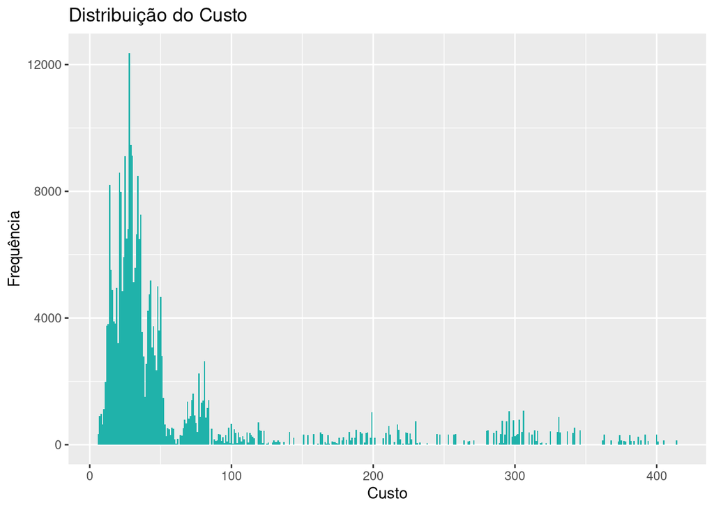

```r
ggplot(sampled_df, aes(x = custo)) + geom_histogram(binwidth = 1, fill = "#20B2AA") +
    labs(title = "Distribuição do Custo", x = "Custo", y = "Frequência")
```

Na distribuição do custo, é possível observar que a maior parte dos produtos possuem um custo entre 0 e 60, o que é um custo razoável para um produto de uma empresa de cosméticos. Porém, existem alguns produtos que possuem um custo muito alto(chegando a até 400), o que pode ser um problema, pois pode indicar que o produto é muito caro para ser produzido, a depender de seu preço.

**Distribuição do Preço de Catálogo**

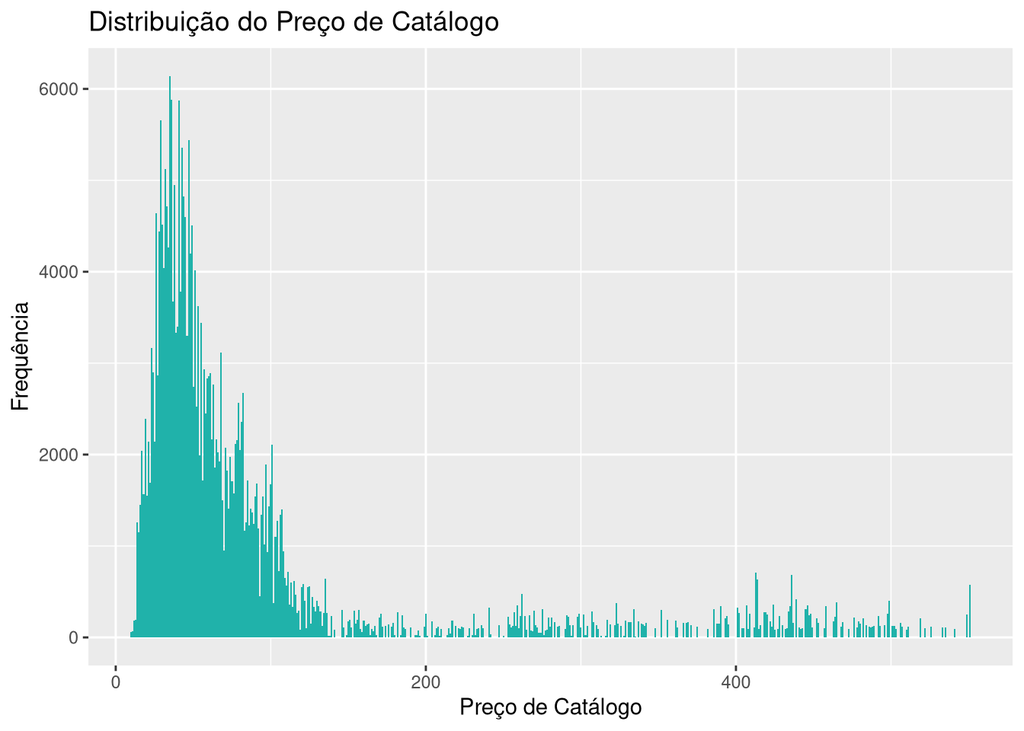

```r
ggplot(sampled_df, aes(x = preco_catalogo)) + geom_histogram(binwidth = 1, fill = "#20B2AA") +
    labs(title = "Distribuição do Preço de Catálogo", x = "Preço de Catálogo", y = "Frequência")
```

Na distribuição do preço de catálogo, é possível observar que a maior parte dos produtos possuem um preço entre 0 e 100, o que é um valor razoável para um produto. Porém, existem alguns produtos que possuem um preço muito alto, o que pode ser um problema, pois pode indicar que o produto tem um valor muito maior do que a média das pessoas compram, porém, por ter uma baixa frequência também pode ser somente um produto de “luxo”.

**Distribuição da Margem de Lucro Bruto**

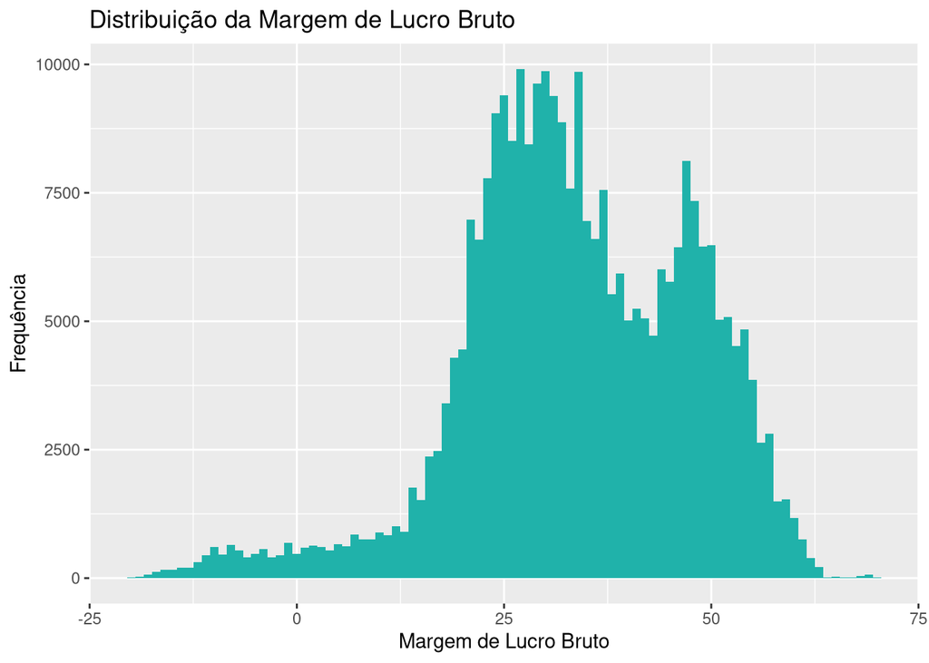

```r
ggplot(sampled_df, aes(x = margem_lucro_bruto_catalogo)) + geom_histogram(binwidth = 1, fill = "#20B2AA") +
    labs(title = "Distribuição da Margem de Lucro Bruto", x = "Margem de Lucro Bruto", y = "Frequência")
```

A distribuição da margem de lucro bruto é uma das mais importantes, pois é a variável que será utilizada para a tomada de decisão dos vendedores. É possível observar que a maior parte dos produtos possuem uma margem de lucro entre 10 e 60, o que é um valor razoável para um produto. Porém, existem alguns produtos que possuem uma margem de lucro muito baixa, o que pode ser um problema, pois pode indicar que o produto é muito caro para ser produzido, ou seja, tem um custo muito alto em relação ao preço.

### Identificação de Outliers

**Identificação de Outliers no Preço**

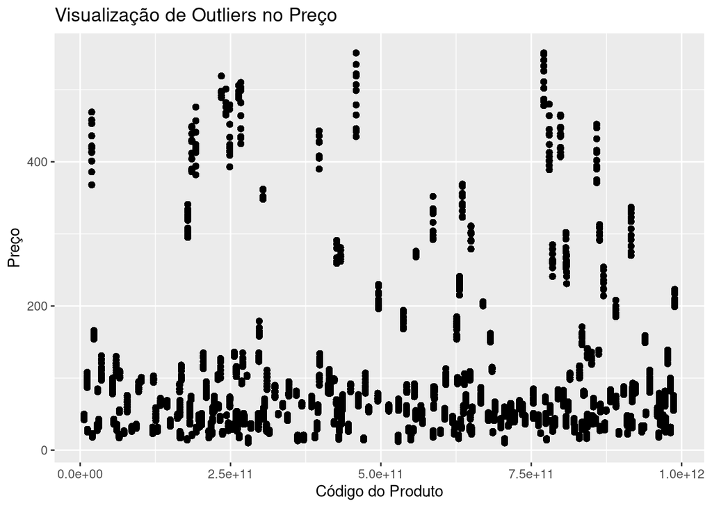

```r
ggplot(sampled_df, aes(x = cod_prod, y = preco_catalogo)) +
  geom_point() +
  labs(title = "Visualização de Outliers no Preço", x = "Código do Produto", y = "Preço")
```

**Identificação de Outliers no Custo**

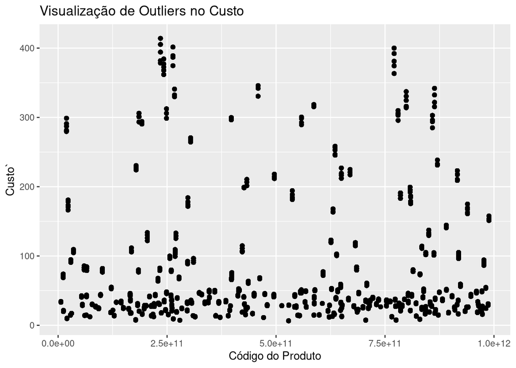

```r
ggplot(sampled_df, aes(x = cod_prod, y = custo)) +
  geom_point() +
  labs(title = "Visualização de Outliers no Custo", x = "Código do Produto", y = "Custo`")
```

Nesses dois gráfico de dispersão, é possível observar que existem alguns custos que fogem do padrão e podem ser considerados Outliers, já que estão significativamente acima da maioria dos outros pontos, que indicam produtos com custos muito maiores que a maioria dos outros, que se concentram em um intervalo de custo entre 0 e 100 R$. No sentido de preços, foi possível observar que a maior parte dos produtos tem preço entre 0 e 200 R$ e que existem alguns produtos com preços muito altos, que podem ser considerados Outliers também.

Algumas suposições podem justificar esses Outliers, como:

- Produtos específicos naturalmente mais caros(Exemplo: Produtos Dior).
- Erros de entrada de dados.

## Análise Bivariada

### Relação entre Preço de Venda e Custo Unitário

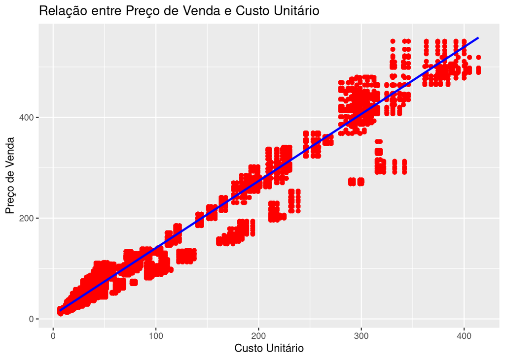

```r
ggplot(sampled_df, aes(x = custo, y = preco_catalogo)) +
  geom_point(color = 'red') +
  geom_smooth(method = 'lm', se = FALSE, color = 'blue') +
  labs(title = 'Relação entre Preço de Venda e Custo Unitário', x = 'Custo Unitário', y = 'Preço de Venda')
```

### Relação entre Margem de Lucro Bruto(Transação) e Região

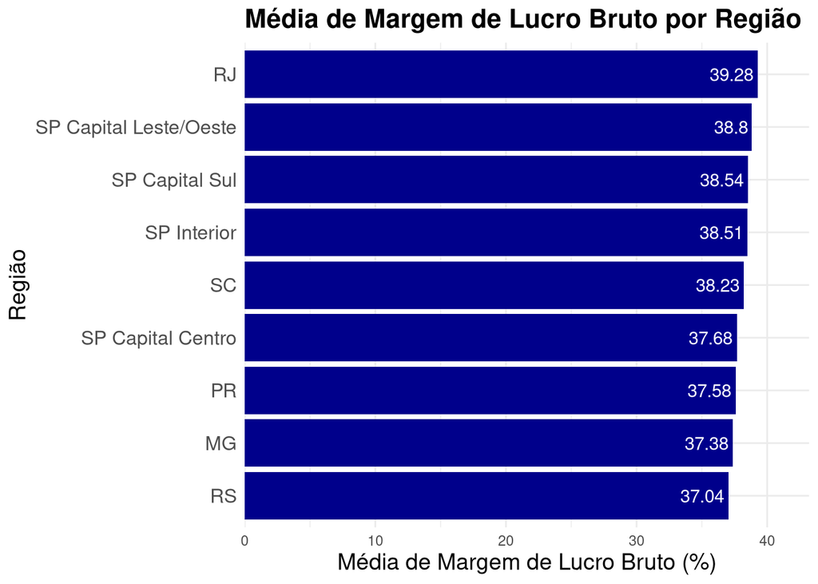

```r
media_margem_por_regiao <- sampled_df %>%
  group_by(regiao) %>%
  summarise(margem_media = mean(margem_lucro_bruto_transacao, na.rm = TRUE))

ggplot(media_margem_por_regiao, aes(x = margem_media, y = reorder(regiao, margem_media))) +
  geom_col(fill = "darkblue") +
  geom_text(aes(label = round(margem_media, 2)),
            hjust = 1.1,
            color = "white") +
  labs(title = "Média de Margem de Lucro Bruto por Região",
       x = "Média de Margem de Lucro Bruto (%)",
       y = "Região") +
  theme_minimal() +
  theme(axis.text.y = element_text(size = 12),
        axis.title = element_text(size = 14),
        plot.title = element_text(size = 16, face = "bold")) +
  scale_x_continuous(expand = expansion(mult = c(0, 0.1)))
```

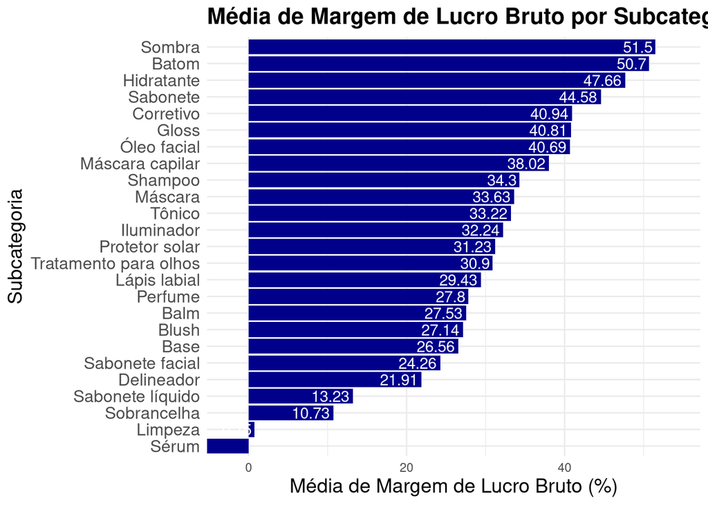

```r
media_margem_por_categoria <- sampled_df %>%
  group_by(sub_categoria) %>%
  summarise(margem_media = mean(margem_lucro_bruto_catalogo, na.rm = TRUE))

ggplot(media_margem_por_categoria, aes(x = margem_media, y = reorder(sub_categoria, margem_media))) +
  geom_col(fill = "darkblue") +
  geom_text(aes(label = round(margem_media, 2)),
            hjust = 1.1,
            color = "white") +
  labs(title = "Média de Margem de Lucro Bruto por Subcategoria",
       x = "Média de Margem de Lucro Bruto (%)",
       y = "Subcategoria") +
  theme_minimal() +
  theme(axis.text.y = element_text(size = 12),
        axis.title = element_text(size = 14),
        plot.title = element_text(size = 16, face = "bold")) +
  scale_x_continuous(expand = expansion(mult = c(0, 0.1)))
```

### Relação entre Margem de Lucro Bruto(Transação) e Categoria

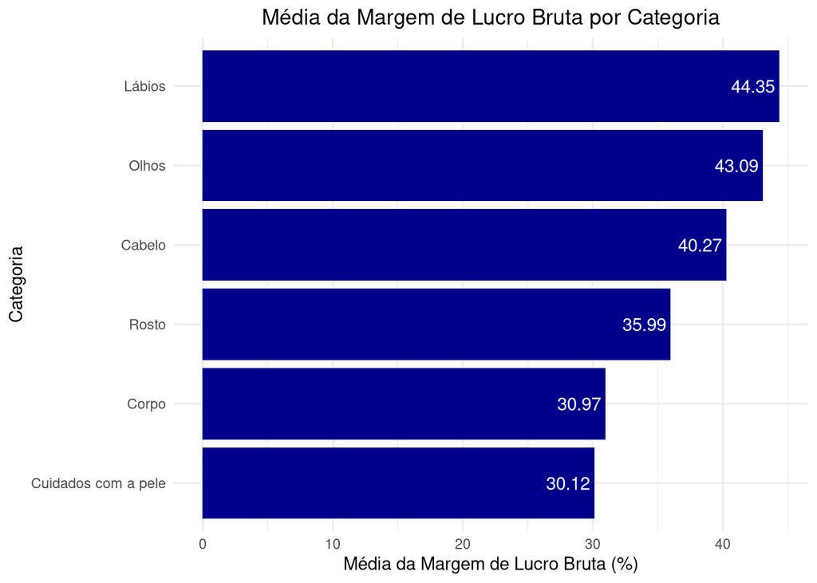

```r
margem_lucro_bruto_categoria <- sampled_df %>%
  group_by(categoria) %>%
  summarise(media_margem = mean(margem_lucro_bruto_transacao, na.rm = TRUE))

ggplot(margem_lucro_bruto_categoria, aes(x = media_margem, y = reorder(categoria, media_margem))) +
  geom_col(fill = "darkblue") +
  geom_text(aes(label = round(media_margem, 2)), hjust = 1.1, color = "white") +
  labs(x = "Média da Margem de Lucro Bruta (%)", y = "Categoria",
       title = "Média da Margem de Lucro Bruta por Categoria") +
  theme_minimal() +
  theme(plot.title = element_text(hjust = 0.5))
```

### Relação entre Custo e Categoria

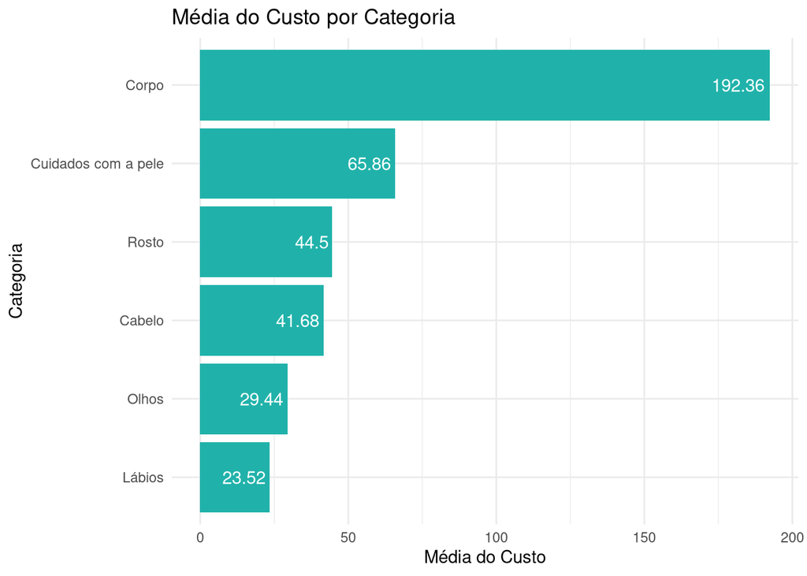

```r
media_custo_categoria <- sampled_df %>%
  group_by(categoria) %>%
  summarise(media_custo = mean(custo, na.rm = TRUE))

ggplot(media_custo_categoria, aes(x = reorder(categoria, media_custo), y = media_custo)) +
  geom_col(fill = "#20B2AA") +
  coord_flip() +
  geom_text(aes(label = round(media_custo, 2)), hjust = 1.1, color = "white") +
  labs(title = "Média do Custo por Categoria",
       x = "Categoria",
       y = "Média do Custo") +
  theme_minimal()
```

### Relação entre Média de Custo e Subcategoria

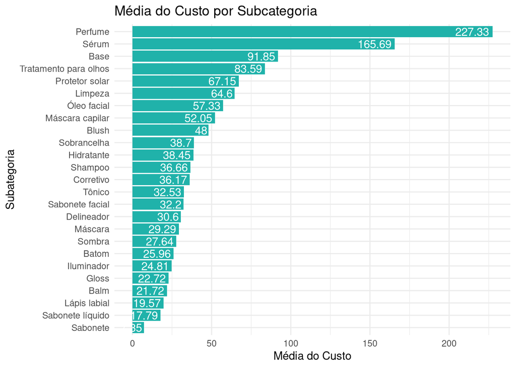

```r
media_custo_categoria <- sampled_df %>%
  group_by(sub_categoria) %>%
  summarise(media_custo = mean(custo, na.rm = TRUE))

ggplot(media_custo_categoria, aes(x = reorder(sub_categoria, media_custo), y = media_custo)) +
  geom_col(fill = "#20B2AA") +
  coord_flip() +
  geom_text(aes(label = round(media_custo, 2)), hjust = 1.1, color = "white") +
  labs(title = "Média do Custo por Subcategoria",
       x = "Subategoria",
       y = "Média do Custo") +
  theme_minimal()
```

### Relação entre Média de Custo e Região

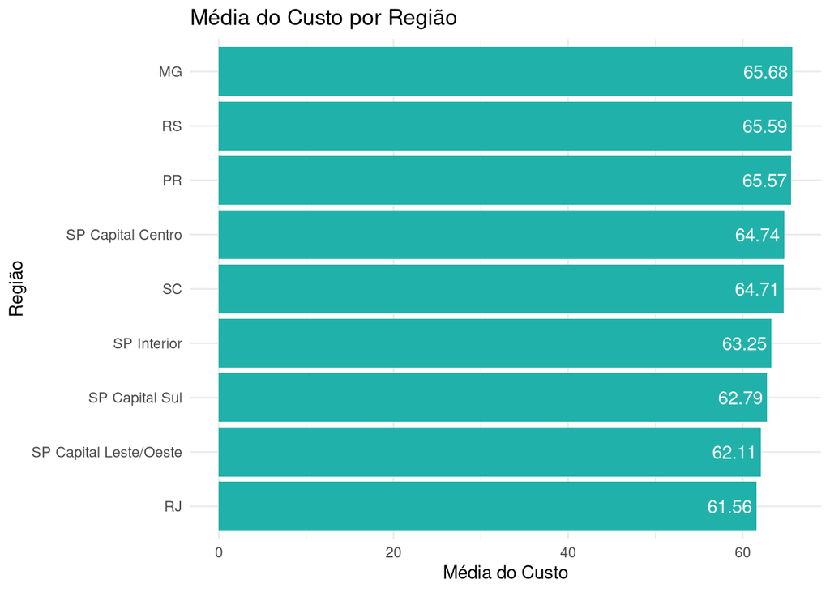

```r
media_custo_regiao <- sampled_df %>%
  group_by(regiao) %>%
  summarise(media_custo = mean(custo, na.rm = TRUE))

ggplot(media_custo_regiao, aes(x = reorder(regiao, media_custo), y = media_custo)) +
  geom_col(fill = "#20B2AA") +
  coord_flip() +
  geom_text(aes(label = round(media_custo, 2)), hjust = 1.1, color = "white") +
  labs(title = "Média do Custo por Região",
       x = "Região",
       y = "Média do Custo") +
  theme_minimal()
```

### Relação entre Média de Preço(Transação) e Categoria

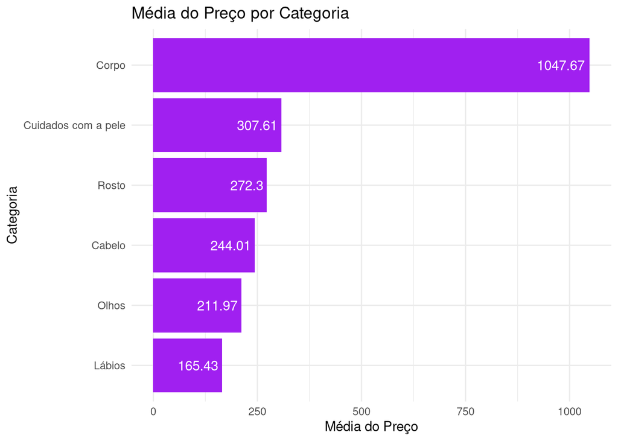

```r
media_preco_categoria <- sampled_df %>%
  group_by(categoria) %>%
  summarise(media_preco = mean(preco_transacao, na.rm = TRUE))

ggplot(media_preco_categoria, aes(x = reorder(categoria, media_preco), y = media_preco)) +
  geom_col(fill = "purple") +
  coord_flip() +
  geom_text(aes(label = round(media_preco, 2)), hjust = 1.1, color = "white") +
  labs(title = "Média do Preço por Categoria",
       x = "Categoria",
       y = "Média do Preço") +
  theme_minimal()
```

### Relação entre Média de Preço(Transação) e Subcategoria

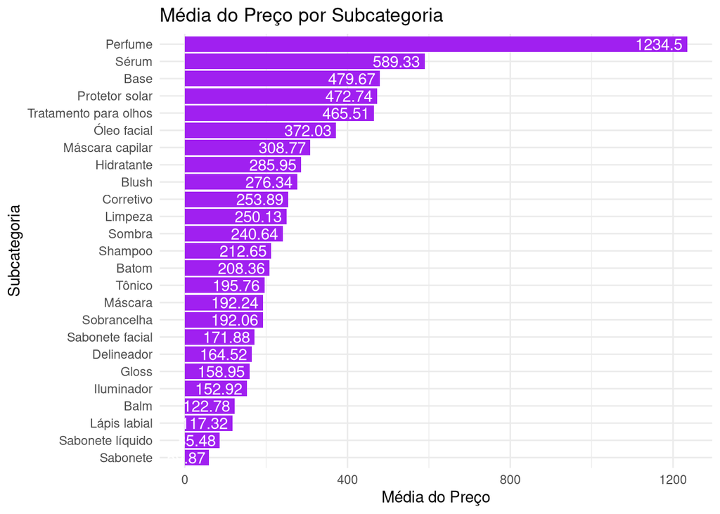

```r
media_preco_categoria <- sampled_df %>%
  group_by(sub_categoria) %>%
  summarise(media_preco = mean(preco_transacao, na.rm = TRUE))

ggplot(media_preco_categoria, aes(x = reorder(sub_categoria, media_preco), y = media_preco)) +
  geom_col(fill = "purple") +
  coord_flip() +
  geom_text(aes(label = round(media_preco, 2)), hjust = 1.1, color = "white") +
  labs(title = "Média do Preço por Subcategoria",
       x = "Subcategoria",
       y = "Média do Preço") +
  theme_minimal()
```

### Relação entre Média de Preço(Transação) e Região

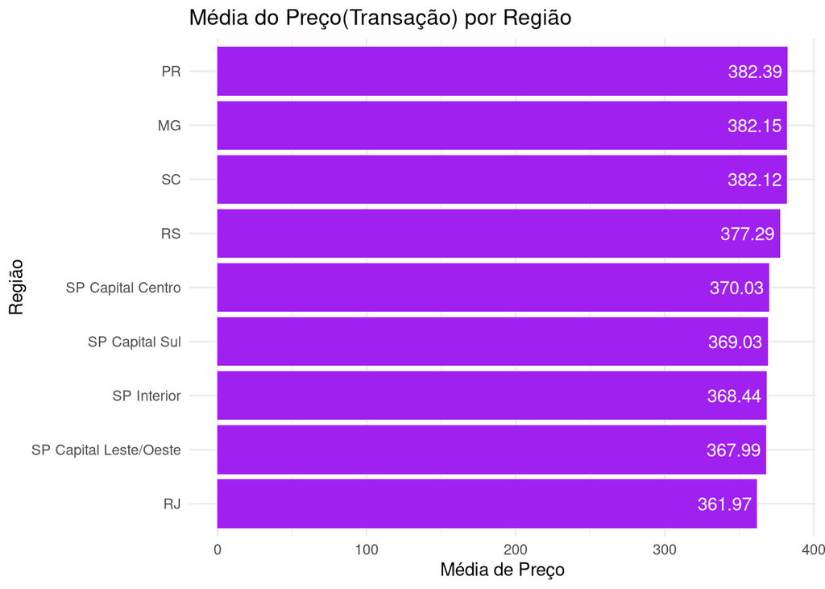

```r
media_preco_regiao <- sampled_df %>%
  group_by(regiao) %>%
  summarise(media_preco = mean(preco_transacao, na.rm = TRUE))

ggplot(media_preco_regiao, aes(x = reorder(regiao, media_preco), y = media_preco)) +
  geom_col(fill = "purple") +
  coord_flip() +
  geom_text(aes(label = round(media_preco, 2)), hjust = 1.1, color = "white") +
  labs(title = "Média do Preço(Transação) por Região",
       x = "Região",
       y = "Média de Preço") +
  theme_minimal()
```